# ROC motif and origins-of-replication sequence analysis in S.cervisiae

philip.east@crick.ac.uk

17/02/2022

# 1 Introduction

## 1.1 Aim

We know that yeast replication origins have (and require) a high affinity binding site for a protein called ORC. We also know that a second ORC must also bind downstream of the high affinity site and in the opposite orientation, and we know that yeast origins have many near matches to the ORC binding site downstream of the high affinity site. We have ~400 replication origins in yeast annotated in oriDB (http://cerevisiae.oridb.org/) on 0.5-1.5kb sequences. We have a 17bp position weight matrix for ORC. We would like to identify the highest PWM score for each origin, align each origin at that sequence and plot the PWM score for each nucleotide of each origin downstream of the best match and average for each position across the 400 origins.

## 1.2 Analysis steps

The details and results from each of these steps are shown below.

# 2 ORC PWM

We read in the probability ORC PWM matrix and transformed it into a PWM object. The maximum match score possible for this PWM is 25.9222.

The `toPWM()` function expands the probability matrix by assuming 50 sequences and rounding to integer values. log2 probability ratios are the calculated from the frequency matrix using this equation, assuming balanced A,C,T and G background probabilities (0.25 each).

priorProbs = prior.params/sum(prior.params)

```r
pwm_file <- file.path( "data", "ORC_PWM_text.txt" )
ORC_motif <- read.delim( file = pwm_file, sep = "\t" ) %>%
    t( )
ORC_motif
```

```
##    [,1]  [,2]  [,3]  [,4]  [,5]  [,6]  [,7]  [,8]  [,9] [,10] [,11] [,12] [,13]
## A 0.288 0.451 0.236 0.253 0.052 0.038 0.160 0.969 0.087 0.288 0.066     0 0.000
## C 0.097 0.021 0.028 0.007 0.000 0.007 0.073 0.000 0.177 0.056 0.000     0 0.007
## G 0.052 0.052 0.028 0.097 0.000 0.003 0.007 0.000 0.000 0.576 0.017     0 0.000
## T 0.563 0.476 0.708 0.642 0.948 0.951 0.760 0.031 0.736 0.080 0.917     1 0.993
##   [,14] [,15] [,16] [,17]
## A 0.517 0.021 0.076 0.104
## C 0.000 0.056 0.076 0.125
## G 0.014 0.708 0.295 0.045
## T 0.469 0.215 0.552 0.726
```

```r
ORC_pwm = toPWM( ORC_motif )
maxScore( ORC_pwm$pwm )
```

```
## [1] 25.9222
```

# 3 OOR sequences

We obtained all S. cerevisiae OOR genomic loci and sequences from [oridb](http://cerevisiae.oridb.org/) [bed file](http://cerevisiae.oridb.org/data_output.php?main=sc_ori&table=sc_ori&ext_format=BED;FASTA;&format=tab) [fasta](http://cerevisiae.oridb.org/cerevisiae_fasta.tgz). We filtered these sequences for those reported as **Confirmed** in the status column of the bed file (N=410).

We descovered ARS302 maps to two overlapping OOR regions. We remvoed these entries from the OOR dataset prior to further analysis. The OOR sequence length distribution is shown below.

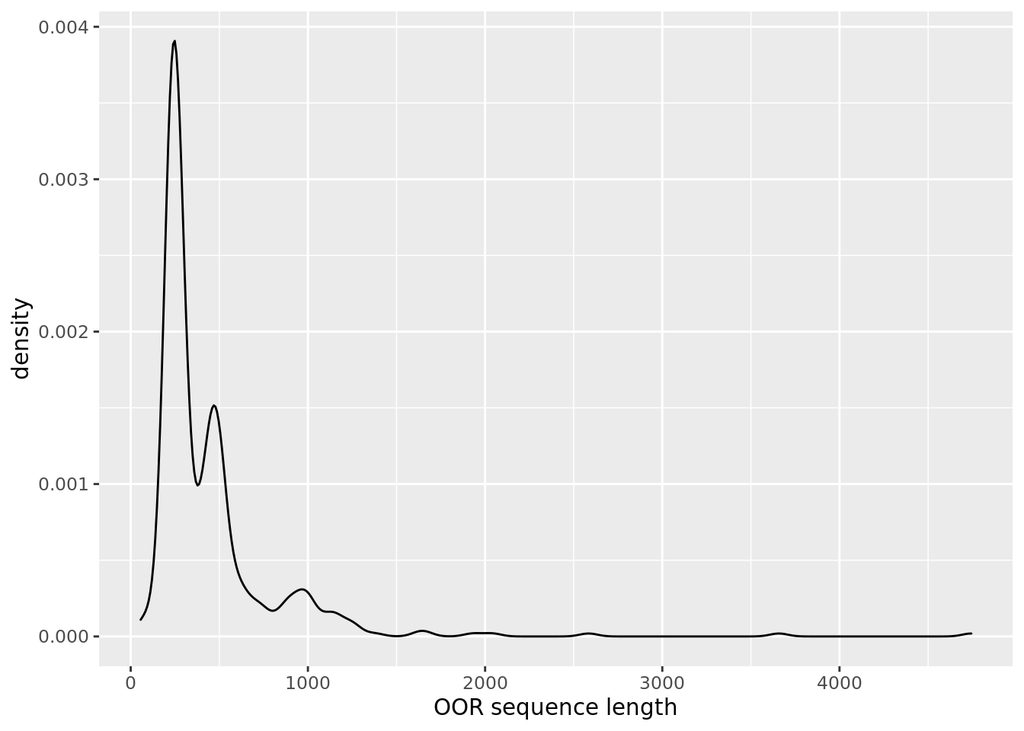

```r
REMOVE_DUPLICATE_ID <- "ARS302"
OOR_bed_file <- file.path( "data", "OOR_data.txt" )
OOR_bed_df <- read.delim( file = OOR_bed_file ) %>%
    mutate( fasta_name = paste0( " range=chr", chr, ":", start, "-", end, " strand=+ species=cerevisiae_dna" ) ) %>%
    filter( status == "Confirmed" ) %>%
    filter( name != REMOVE_DUPLICATE_ID )
target_seqs_fa_file <- file.path( "data", "OOR_scerevisiae.fastq" )
target_seqs <- readDNAStringSet( target_seqs_fa_file )
target_seqs <- target_seqs[ names( target_seqs ) %in% OOR_bed_df$fasta_name ]

OOR_length_dist_gg <- data.frame( OOR_length = width( target_seqs ) ) %>%
    ggplot( aes( x = OOR_length ) ) +
    geom_density( ) +
    labs( x = "OOR sequence length" )
print( OOR_length_dist_gg )
```

# 4 Run ORC PWM search

We ran a PWM search against the OOR sequences. We applied a minimum match score threshold of 0% to obtain all possible hits. This percentage score is the ratio of the hit score over the max score for the PWM represented as a percentage (see above).

```r
ORC_matches_raw <- map( 1:length( target_seqs ), function( seq_i ) {
    hit_f <- matchPWM( ORC_pwm$pwm, target_seqs[[ seq_i ]], with.score = TRUE, min.score = 0 )
    if( length( hit_f ) > 0 )
        mcols( hit_f )$strand <- 1
    hit_r <- matchPWM( reverseComplement( ORC_pwm$pwm ), target_seqs[[ seq_i ]],
                      with.score = TRUE, min.score = "0%" )
    if( length( hit_r ) > 0 )
        mcols( hit_r )$strand <- -1
    df <- data.frame( start = c( start( hit_f ), start( hit_r ) ),
                     end = c( end( hit_f ), end( hit_r ) ),
                     width = c( width( hit_f ), width( hit_r ) ),
                     score = c( mcols( hit_f )$score, mcols( hit_r )$score ),
                     strand = c( mcols( hit_f )$strand, mcols( hit_r )$strand ),
                     seq_length = length( target_seqs[[ seq_i ]] ) )
} ) %>%
    setNames( names( target_seqs ) )

OOR_regions2names_df <- data.frame( fasta_name = names( ORC_matches_raw ) ) %>%
    left_join( OOR_bed_df, by = "fasta_name" )
names( ORC_matches_raw ) <- OOR_regions2names_df$name
```

# 5 Annotate A and B elements

For each OOR we identified the A-element as the highest scoring ORC match. We labelled all downstream elements in the opposite orientation to the A-element as B-elements.

We removed two OORs with multiple maximum ORC matches since we could not identify the true ORC A-element.

We also removed 18 OORs with zero B-elements.

```r
max_filter <- ORC_matches_raw %>%
    map( function( df ) sum( df$score == max( df$score ) ) ) %>%
    unlist( )
ORC_matches_raw <- ORC_matches_raw[ max_filter == 1 ] %>%
    map( mutate, midpoint = (start + ((end-start)/2)) )
```

```r
ORC_matches <- ORC_matches_raw %>%
    map( function( df ) {
        a_element <- df %>%
            filter( score == max( score ) )
        df %>%
            mutate( element = NA ) %>%
            mutate( element = ifelse( score == max( score ), "A-element", NA ) ) %>%
            rowwise( ) %>%
            mutate( element = ifelse( a_element$strand == 1,
                              ifelse( start > a_element$end & strand == -1 & is.na( element ), "B-element", element ),
                              ifelse( end < a_element$start & strand == 1 & is.na( element ), "B-element", element ) ) ) %>%
            filter( !is.na( element ) ) %>%
            mutate( distance = ifelse( a_element$strand == 1, (midpoint - a_element$midpoint), a_element$midpoint - midpoint ) ) %>%
            mutate( distance = ifelse( element == "A-element", 0, distance ) ) %>%
            ungroup( )
    } )
## remove OORs with zero B-elements
b_element_count <- ORC_matches %>%
    map( function( df ) sum( df$element == "B-element" ) ) %>%
   unlist( )
ORC_matches <- ORC_matches[ b_element_count > 0 ]
```

# 6 Positive control - ARS416

We used ARS416 to define the distance from the A-element to the primary B-element (score > 10, 43 bp, match boundary to boundary). The ORC A and B-elements for ARS416 are shown in the table below.

We counted the number of OORs with a primary B-element <= 43 bp, 43 > & <= 400bp and > 400 bp. The counts for each region are independent so the same OOR could have been counted more than once if it had a B-element with a score > 10 in each region. These results are shown below (score > 10).

```r
ARS416_boundary <- 43+8+9
outer_boundary <- 400
ORC_matches$ARS416 %>% DT::datatable( rownames = FALSE )
```

| start | end | width | score | strand | seq_length | midpoint | element | distance |
| --- | --- | --- | --- | --- | --- | --- | --- | --- |
| 94 | 110 | 17 | 3.06910225319184 | 1 | 270 | 102 | B-element | 65 |
| 100 | 116 | 17 | 13.681045620019 | 1 | 270 | 108 | B-element | 59 |
| 101 | 117 | 17 | 2.31133344619184 | 1 | 270 | 109 | B-element | 58 |
| 104 | 120 | 17 | 1.0072039145271 | 1 | 270 | 112 | B-element | 55 |
| 159 | 175 | 17 | 17.777876796083 | -1 | 270 | 167 | A-element | 0 |

```r
ORC_matches %>%
    map( function( df ) {
        df %>%
            filter( element == "B-element" & score > SCORE_THRESHOLD ) %>%
            summarize( lt_43 = sum( distance <= ARS416_boundary ),
                      gt_43_and_lt400 = sum( distance > ARS416_boundary & distance <= outer_boundary ),
                      gt_400 = sum( distance > outer_boundary ) )
    } ) %>%
    bind_rows( ) %>%
    colSums( ) %>%
    as.data.frame( ) %>%
    rename( count = 1 ) %>%
    rownames_to_column( var = "region" ) %>%
    DT::datatable( )
```

|  | region | count |
| --- | --- | --- |
| 1 | lt_43 | 96 |
| 2 | gt_43_and_lt400 | 243 |
| 3 | gt_400 | 37 |

# 7 Ranked maximum B-element plot

We plotted the maximum B-element score against maximum B-element score rank for each OOR to determine the B-element score threshold to select 80% of the OORs with as least one B-element. This value is printed below.

Please note the 80% is calculated from the filtered OOR set where OORs with zero B-elements or multiple A-elements have been removed.

```r
plotdat <- ORC_matches %>%
    map( filter, element == "B-element" ) %>%
    map( filter, score == max( score ) ) %>%
    map( filter, row_number( ) == 1 ) %>%
    bind_rows( .id = "OOR_id" ) %>%
    arrange( desc( score ) ) %>%
    mutate( rank = 1:nrow(.) / nrow( . ) * 100 )

score_thr_80 <- plotdat %>%
    filter( rank > 80 ) %>%
    filter( row_number( ) == 2 ) %>%
    pull( score )
score_thr_80
```

```
## [1] 5.434252
```

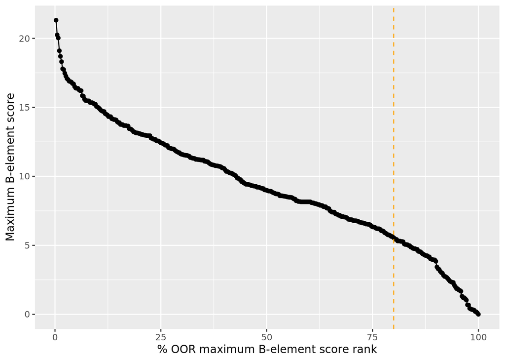

```r
gg <- plotdat %>%
    ggplot( aes( x = rank, y = score ) ) +
    geom_line( ) +
    geom_point( ) +
    geom_vline( xintercept = 80, color = "orange", linetype = "dashed" ) +
    labs( x = "% OOR maximum B-element score rank",
         y = "Maximum B-element score" )
print( gg )
```

# 8 Mean B-elements per OOR

We calculated the mean number of B-elements per OOR at the 80% inclusion threshold 5.4342522 calculated above. The value and distribution are shown below.

```r
b_elements_n <- ORC_matches %>%
    map( filter, element == "B-element" ) %>%
    map( filter, score >= score_thr_80 ) %>%
    map( nrow ) %>%
    unlist( )

mean( b_elements_n )
```

```
## [1] 3.167526
```

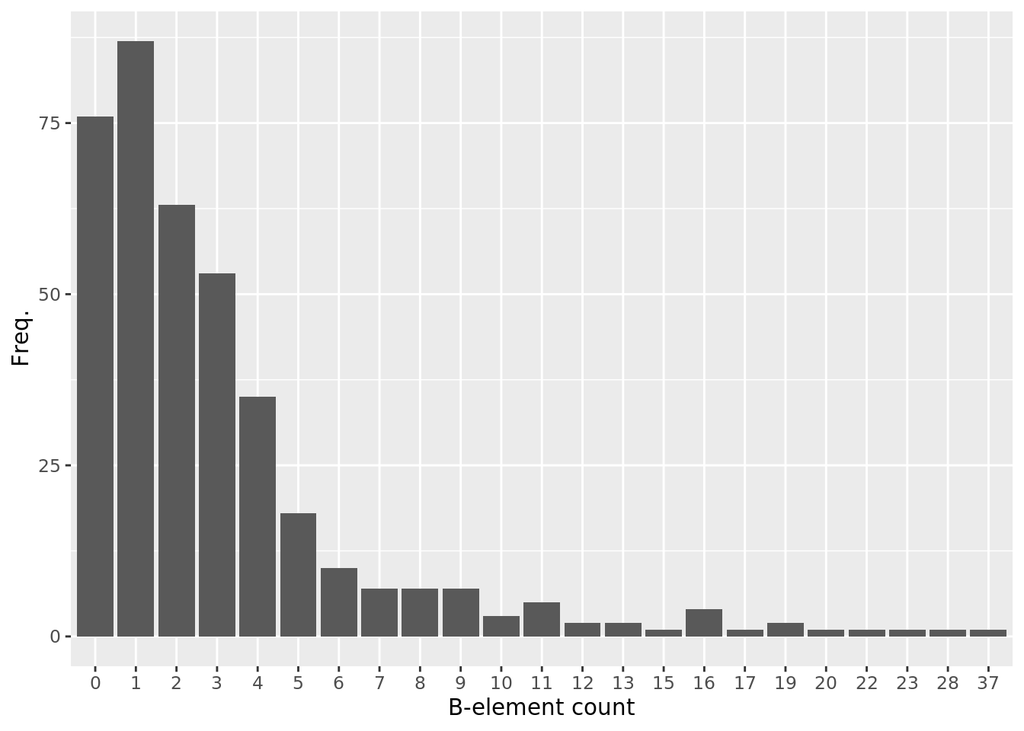

```r
mean_b_element_bar_gg <- table( b_elements_n ) %>%
    as.data.frame( ) %>%
    ggplot( aes( x = b_elements_n, y = Freq ) ) +
    geom_bar( stat = "identity" ) +
    labs( x = "B-element count", y = "Freq." )
print( mean_b_element_bar_gg )
```

# 9 Mean distance to first B-element

We calculated the distance to the first B-element with a score above the 5.4342522 threshold calculated above. This value is printed below.

```r
belement_dist_plotdat <- ORC_matches %>%
    map( filter, element == "B-element" ) %>%
    map( filter, score >= score_thr_80 ) %>%
    map( arrange, distance ) %>%
    map( filter, row_number( ) == 1 ) %>%
    bind_rows( )

belement_dist_plotdat %>%
    pull( distance ) %>%
    mean( )
```

```
## [1] 81.63141
```

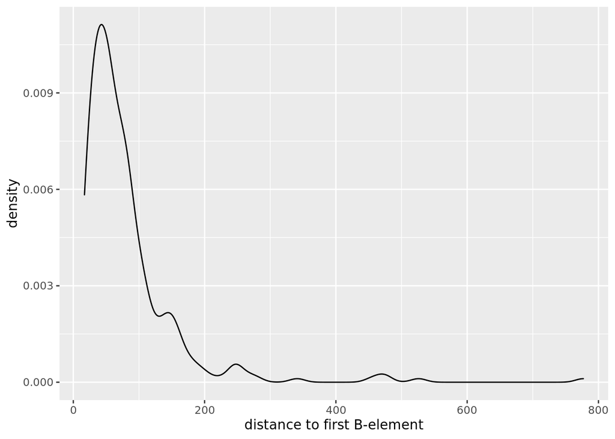

```r
belement_dist_gg <- belement_dist_plotdat %>%
    ggplot( aes( x = distance ) ) +
    geom_density( ) +
    labs( x = "distance to first B-element" )
print( belement_dist_gg )
```

# 10 Output data

We wrote A and B-element annotated ORC matches and raw ORC matches to an Excel file. There are two worksheets, **AB-elements** contains the annotated A and B-elements in long format. The column definitions for these data are shown below. **all_ORC_hits** contains all reported ORC matches with a subset of the columns described below.

The file can be downloaded here

```r
dbase_l <- list( 'AB-elements' = ORC_matches %>%
                     bind_rows( .id = "OOR_id" ) %>%
                     mutate( pass_80pc_thr = score >= score_thr_80 ),
                 all_ORC_hits = ORC_matches_raw %>%
                     bind_rows( .id = "OOR_id" ) )

dbase_l %>%
    write.xlsx( "AB-element_ORC_OOR_data.xlsx" )
```

# 11 AB-element dotplot

A pdf version of the plot can be downloaded here

```r
max_score_b_dist_ord <- ORC_matches %>%
    map( filter, element == "B-element" ) %>%
    map( filter, score == max( score ) ) %>%
    map( filter, row_number( ) == 1 ) %>%
    map( dplyr::select, distance ) %>%
    map( pull, distance ) %>%
    unlist( ) %>%
    sort( )
```

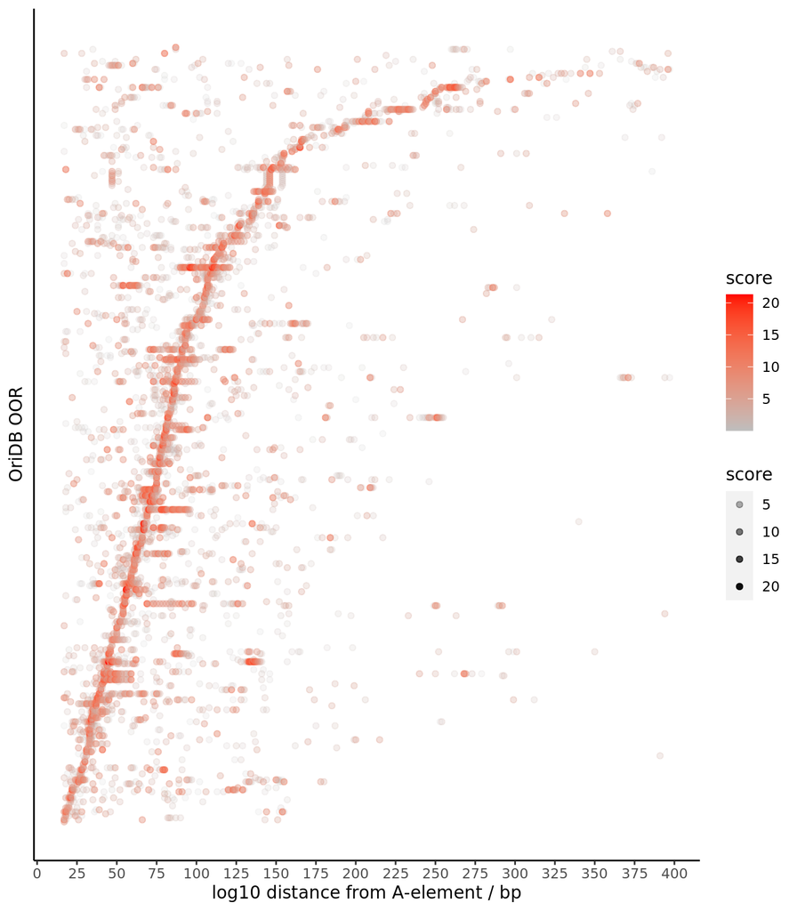

```r
dotplot_df <- ORC_matches %>%
    bind_rows( .id = "OOR_id" ) %>%
    filter( element == "B-element" ) %>%
    mutate( pass_80pc_thr = score >= score_thr_80 ) %>%
    arrange( distance ) %>%
    mutate( OOR_id = factor( OOR_id, levels = names( max_score_b_dist_ord ) ) ) %>%
    filter( distance <= 400 ) %>%
    mutate( order = as.numeric( OOR_id ) )

dbase <- list( heatmap_data = dotplot_df )

ab_element_dotplot_gg <- dotplot_df %>%
    ggplot( aes( x = distance, y = as.numeric( OOR_id ), color = score, alpha = score ) ) +
    geom_point(  ) +
    ##scale_x_continuous( trans = 'log10' ) +
    scale_color_gradient( low = "grey", high = "red" ) +
    labs( x = "log10 distance from A-element / bp", y = "OriDB OOR" ) +
    scale_x_continuous( breaks = seq( 0, 400, by = 25 ) ) +
    theme(
        axis.line = element_line( ),
        axis.text.y = element_blank( ),
        axis.ticks.y = element_blank( ),
        panel.grid.major = element_blank( ),
        panel.grid.minor = element_blank( ),
        panel.background = element_blank( ) )

print( ab_element_dotplot_gg )
```

```r
cairo_pdf( file = file.path( "results", "ab-element_dotplot.pdf" ), height = 10 )
print( ab_element_dotplot_gg )
dev.off( )
```

# 12 Mean score profile plot

We aligned and orientated each OOR around its A-element. We took the mean of the ORC match scores per base for all B-elements across all aligned OORs. This plot is shown below.

A pdf version of the plot can be downloaded here

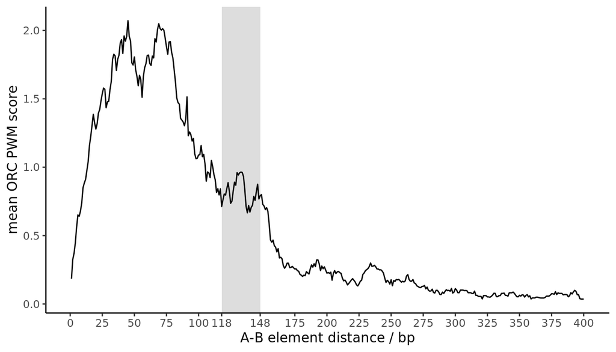

```r
xscale <- seq( 0, 400, by = 25 )
xscale[ xscale == 125 ]  <- 118
xscale[ xscale == 150 ]  <- 148

ORC_matches_flipped <- ORC_matches %>%
    map( function( df ) {
        a_element_df <- df %>%
            filter( element == "A-element" )
        df <- df %>%
            filter( element == "B-element" )
        if( a_element_df$strand == 1 ) {
            df %>%
                mutate( start = start - a_element_df$end ) %>%
                mutate( end = end - a_element_df$end )
        } else {
            df %>%
                mutate( start_new = a_element_df$start - end ) %>%
                mutate( end = a_element_df$start - start ) %>%
                mutate( start = start_new ) %>%
                dplyr::select( -start_new )
        }
    } )

max_b_element_coor <- ORC_matches_flipped %>%
    map( function( df ) max( df$end ) ) %>%
    unlist( ) %>%
    max( )

roc_mat <- matrix( 0, nrow = length( ORC_matches_flipped ), ncol = max_b_element_coor )

coors_vec <- map( ORC_matches_flipped, function( df ) {
    df %>%
        rowwise( ) %>%
        mutate( coor = list( start:end ) ) %>%
        pull( coor ) %>%
        unlist( )
} )

score_vec <- map( ORC_matches_flipped, function( df ) {
    rep( df$score, each = 17 )
} )

OOR_ind <- sapply( 1:length( ORC_matches_flipped ), function( ind ) {
    rep( ind, ( nrow( ORC_matches_flipped[[ ind ]] ) * 17 ) )
} ) %>%
    unlist( )

for( i in 1:nrow( roc_mat ) )
    roc_mat[ i, coors_vec[[ i ]] ] <- score_vec[[ i ]]

plotdat <- data.frame( mean_roc_vec = colMeans( roc_mat ),
                       coor = 1:ncol( roc_mat ) )

gg <- plotdat %>%
    filter( coor <= 400 ) %>%
    ggplot( aes( x = coor, y = mean_roc_vec ) ) +
    geom_rect( aes( xmin = 118, xmax = 148, ymin = -Inf, ymax = Inf), fill = "#DDDDDD", inherit.aes = FALSE ) +
    geom_line( ) +
    scale_x_continuous( breaks = xscale ) +
    labs( x = "A-B element distance / bp",
         y = "mean ORC PWM score" ) +
    theme(
        axis.line = element_line( ),
        panel.grid.major = element_blank( ),
        panel.grid.minor = element_blank( ),
        panel.background = element_blank( ) )
print( gg )
```

```r
cairo_pdf( file = file.path( "results", "B-elements_sum_profile_plot.pdf" ), height = 4 )
print( gg )
dev.off( )
```